# 5663354

# Data Visualisation

In this section, we examine the distributions of key variables using histograms. Visualizing data distributions provides insights into their spread, central tendencies, and possible skewness, helping us better understand the dataset.

## 1.Distribution of Variables

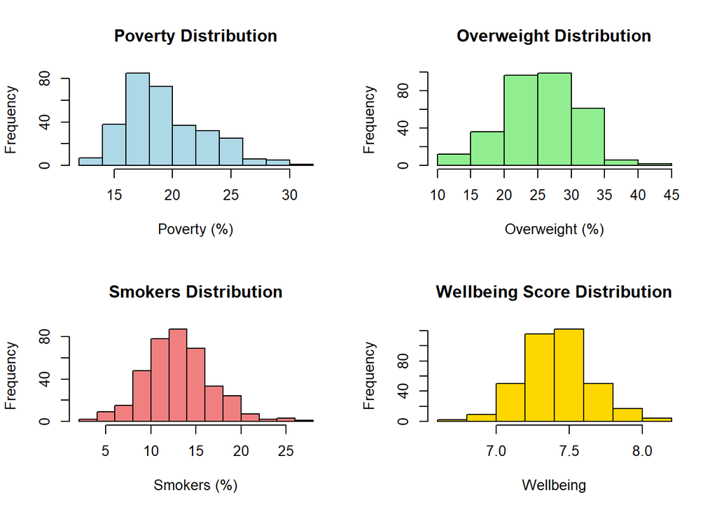

```r
# Histograms
par(mfrow = c(2, 2))
hist(data$Poverty, col = "lightblue", main = "Poverty Distribution", xlab = "Poverty (%)")
hist(data$overweight, col = "lightgreen", main = "Overweight Distribution", xlab = "Overweight (%)")
hist(data$smokers, col = "lightcoral", main = "Smokers Distribution", xlab = "Smokers (%)")
hist(data$wellbeing, col = "gold", main = "Wellbeing Score Distribution", xlab = "Wellbeing")
```

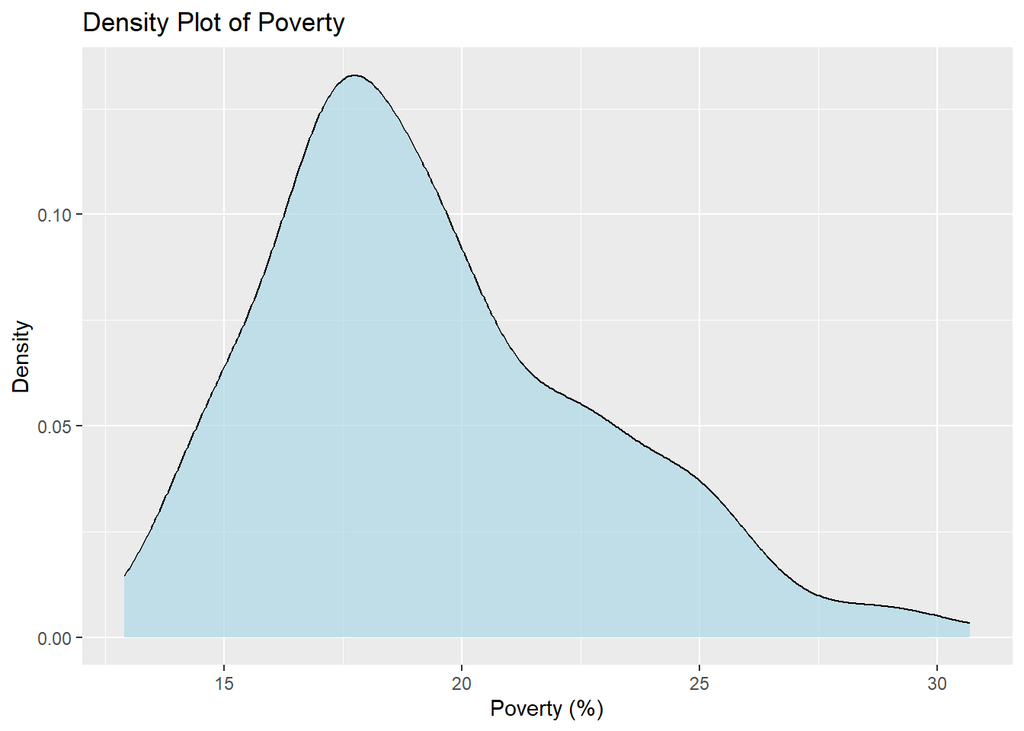

```r
# Density plots
ggplot(data, aes(x = Poverty)) +
  geom_density(fill = "lightblue", alpha = 0.7) +
  labs(title = "Density Plot of Poverty", x = "Poverty (%)", y = "Density")
```

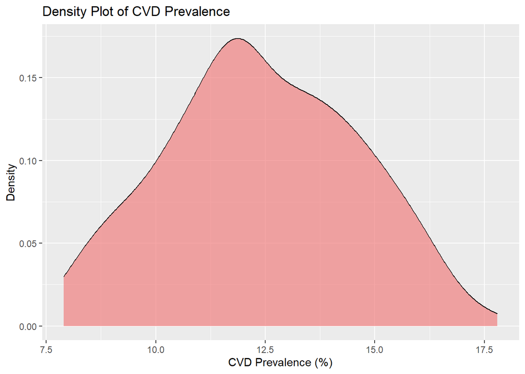

```r
ggplot(data, aes(x = CVD)) +
  geom_density(fill = "lightcoral", alpha = 0.7) +
  labs(title = "Density Plot of CVD Prevalence", x = "CVD Prevalence (%)", y = "Density")
```

Explored the distributions of poverty, overweight, smokers, and wellbeing variables. Identified potential patterns such as skewness or uniformity in variable distributions.

## 2.Pairwise Relationships

Scatterplots visualize relationships between predictors and CVD prevalence, helping identify potential trends or associations.

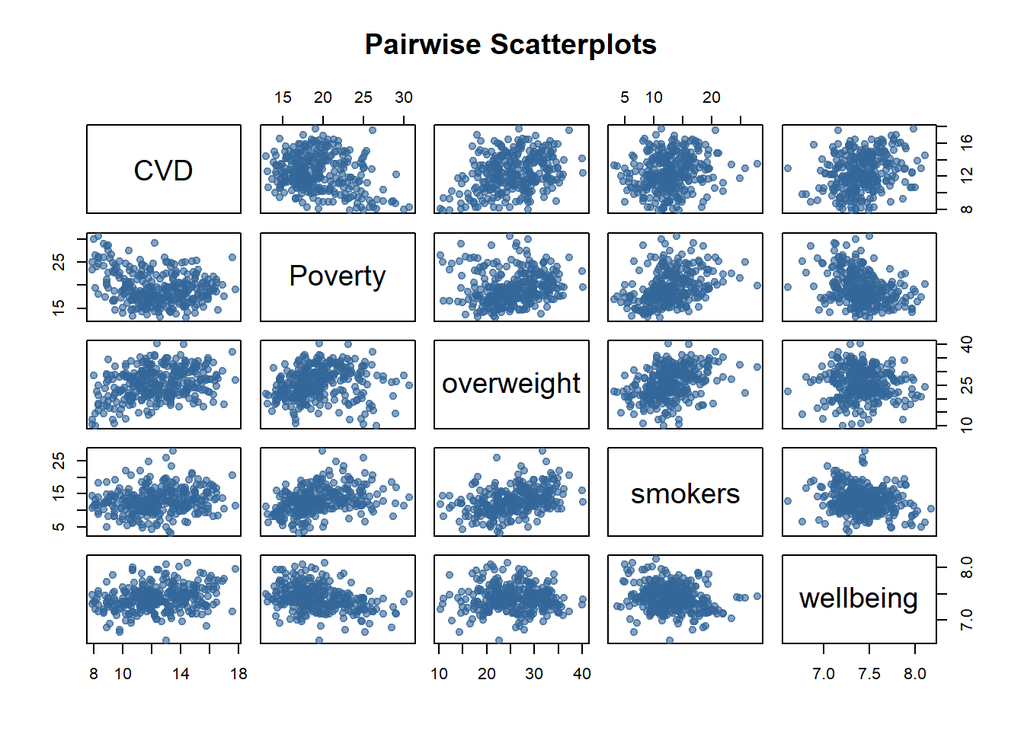

```r
pairs(data[, c("CVD", "Poverty", "overweight", "smokers", "wellbeing")],
      main = "Pairwise Scatterplots",
      pch = 19,
      col = rgb(0.2, 0.4, 0.6, 0.6))
```

## 3.Group Comparisons with Boxplots

Boxplots help compare the distribution of CVD prevalence across categories such as high vs. low poverty or smoking levels.

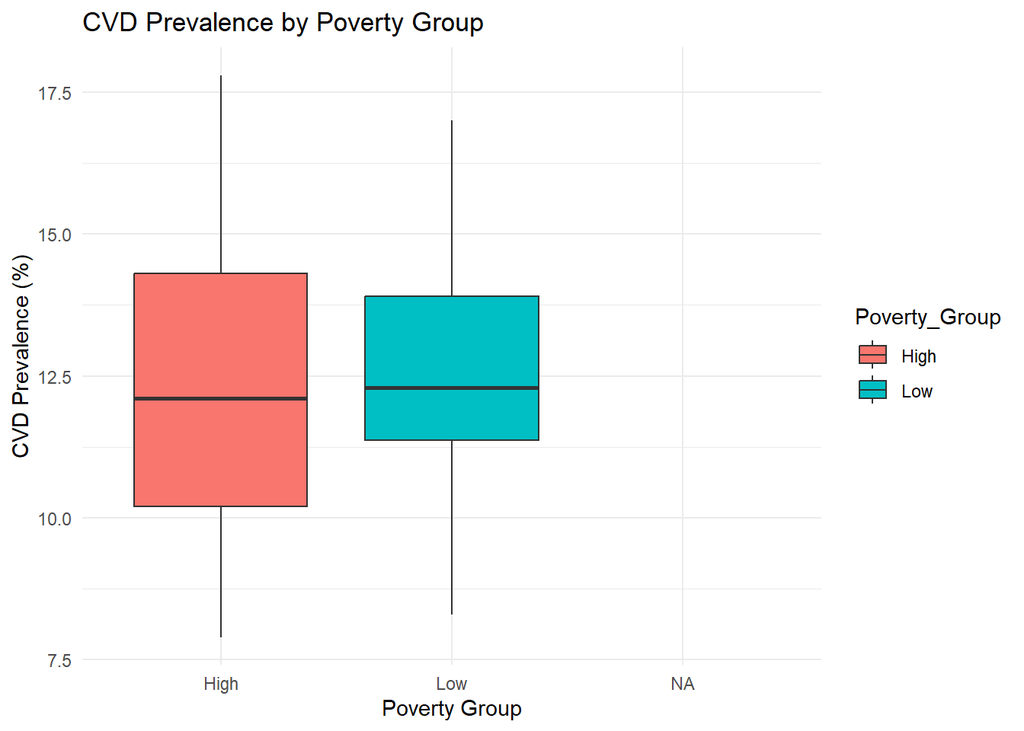

```r
# Categorizing poverty into high and low groups
data$Poverty_Group <- ifelse(data$Poverty > median(data$Poverty, na.rm = TRUE), "High", "Low")

# Boxplot for CVD prevalence by poverty group
ggplot(data, aes(x = Poverty_Group, y = CVD, fill = Poverty_Group)) +
  geom_boxplot() +
  labs(title = "CVD Prevalence by Poverty Group", x = "Poverty Group", y = "CVD Prevalence (%)") +
  theme_minimal()
```

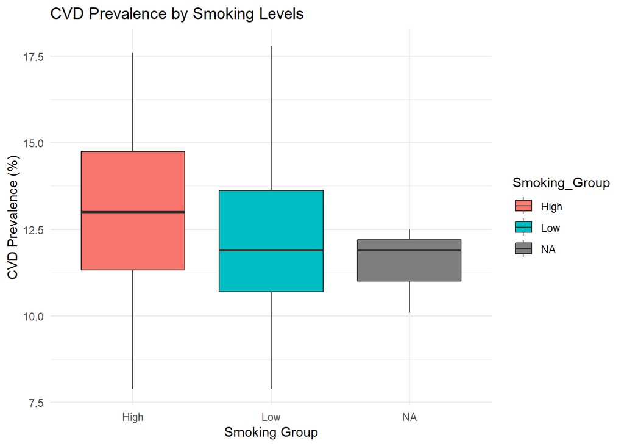

```r
# Boxplot for CVD prevalence by smoking levels
data$Smoking_Group <- ifelse(data$smokers > median(data$smokers, na.rm = TRUE), "High", "Low")
ggplot(data, aes(x = Smoking_Group, y = CVD, fill = Smoking_Group)) +
  geom_boxplot() +
  labs(title = "CVD Prevalence by Smoking Levels", x = "Smoking Group", y = "CVD Prevalence (%)") +
  theme_minimal()
```

## 4.Visualizing Trends

Scatterplots with regression lines show the trend and strength of relationships between predictors and CVD prevalence.

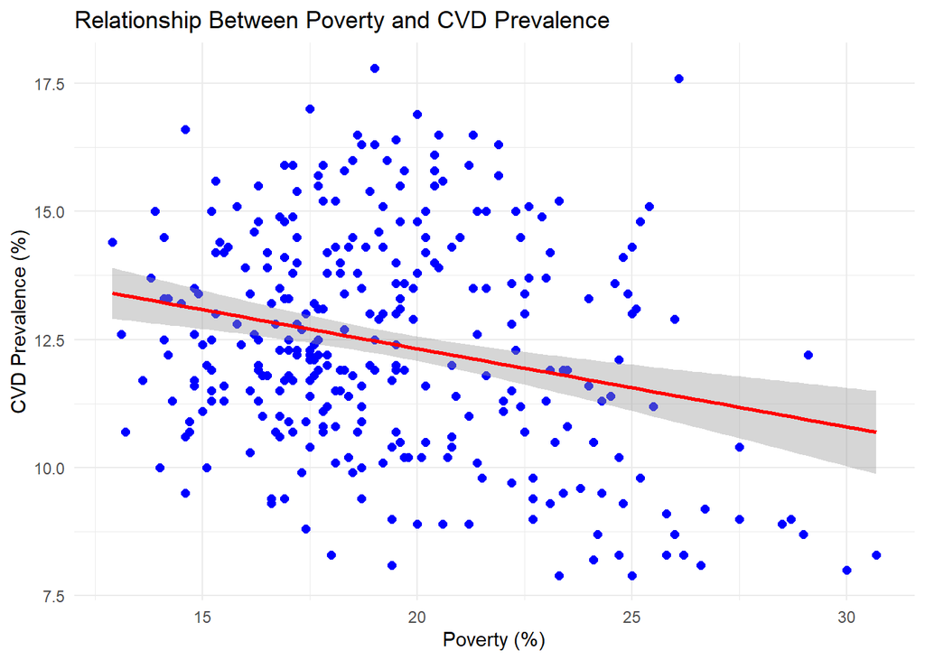

```r
# Poverty vs. CVD Prevalence
ggplot(data, aes(x = Poverty, y = CVD)) +
  geom_point(color = "blue", size = 2) +
  geom_smooth(method = "lm", color = "red") +
  labs(title = "Relationship Between Poverty and CVD Prevalence", x = "Poverty (%)", y = "CVD Prevalence (%)") +
  theme_minimal()
```

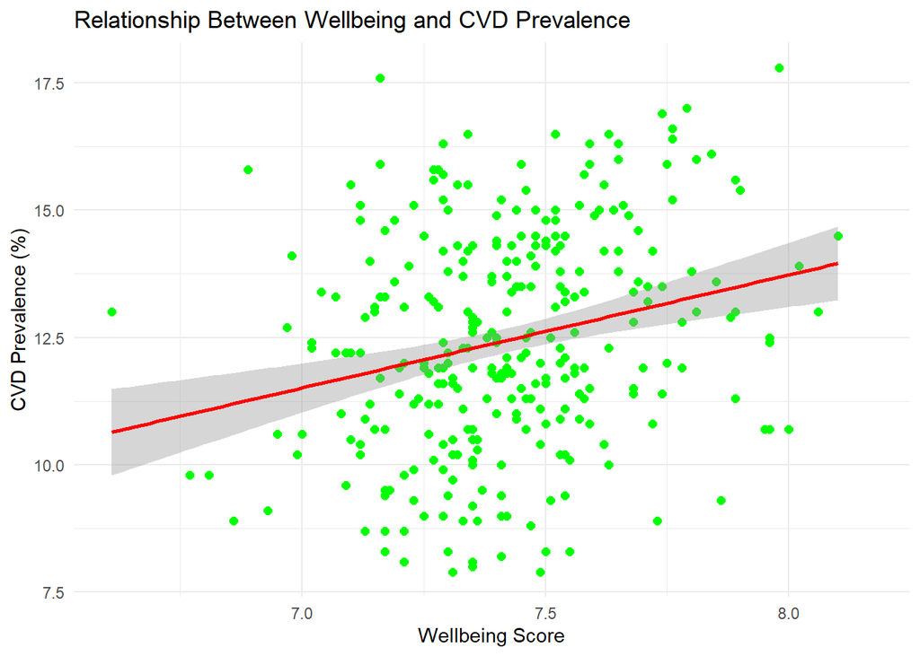

```r
# Wellbeing vs. CVD Prevalence
ggplot(data, aes(x = wellbeing, y = CVD)) +
  geom_point(color = "green", size = 2) +
  geom_smooth(method = "lm", color = "red") +
  labs(title = "Relationship Between Wellbeing and CVD Prevalence", x = "Wellbeing Score", y = "CVD Prevalence (%)") +
  theme_minimal()
```

# Correlation Analysis

Correlation analysis measures the strength and direction of linear relationships between variables. This helps identify which independent variables (e.g., poverty, overweight, smokers, wellbeing) are strongly associated with CVD prevalence, providing a preliminary understanding of their potential impact.

```r
# Correlation matrix
cor_matrix <- cor(data[, c("CVD", "Poverty", "overweight", "smokers", "wellbeing")], use = "complete.obs")
print(cor_matrix)
```

```
##                   CVD    Poverty  overweight    smokers   wellbeing
## CVD         1.0000000 -0.2480841  0.31900420  0.1778206  0.24536584
## Poverty    -0.2480841  1.0000000  0.13933765  0.3613067 -0.34510391
## overweight  0.3190042  0.1393377  1.00000000  0.4033591 -0.04183724
## smokers     0.1778206  0.3613067  0.40335911  1.0000000 -0.19895474
## wellbeing   0.2453658 -0.3451039 -0.04183724 -0.1989547  1.00000000
```

Quantified relationships between variables. Identified predictors that might have a strong or weak association with CVD prevalence.

# Part 1: Analyzing Predictors of CVD Prevalence

In this step, we perform linear regression to analyze how predictors such as poverty, overweight, smokers, and wellbeing influence CVD prevalence. This statistical model provides estimates of the effect size and significance for each predictor.

## T-test and Linear Model Analysis

```r
# Linear model
model <- lm(CVD ~ Poverty + overweight + smokers + wellbeing, data = data)
summary(model)
```

```
##
## Call:
## lm(formula = CVD ~ Poverty + overweight + smokers + wellbeing,
##     data = data)
##
## Residuals:
##     Min      1Q  Median      3Q     Max
## -4.3966 -1.4313 -0.1097  1.3905  4.7779
##
## Coefficients:
##             Estimate Std. Error t value Pr(>|t|)
## (Intercept) -1.69780    3.93361  -0.432 0.666335
## Poverty     -0.18400    0.03515  -5.234 3.13e-07 ***
## overweight   0.10985    0.02123   5.174 4.22e-07 ***
## smokers      0.12030    0.03366   3.574 0.000410 ***
## wellbeing    1.80025    0.49096   3.667 0.000291 ***
## ---
## Signif. codes:  0 '***' 0.001 '**' 0.01 '*' 0.05 '.' 0.1 ' ' 1
##
## Residual standard error: 1.894 on 298 degrees of freedom
##   (82 observations deleted due to missingness)
## Multiple R-squared:  0.2494, Adjusted R-squared:  0.2393
## F-statistic: 24.75 on 4 and 298 DF,  p-value: < 2.2e-16
```

Identified significant predictors of CVD prevalence based on p-values. Quantified the impact of each predictor on CVD prevalence through regression coefficients.

# Multicollinearity Check

Multicollinearity occurs when independent variables are highly correlated with each other, which can distort regression results. Variance Inflation Factor (VIF) values help detect multicollinearity. A VIF greater than 5 indicates potential issues.

```r
# Variance Inflation Factor (VIF)
vif_values <- vif(model)
print(vif_values)
```

```
##    Poverty overweight    smokers  wellbeing
##   1.263094   1.196546   1.359206   1.145506
```

This Confirmed that multicollinearity does not affect the regression model, ensuring reliable estimates.

# Part 2: Visualizing Relationships

## Scatterplot of Poverty and CVD

A scatterplot illustrates the relationship between poverty and CVD prevalence.

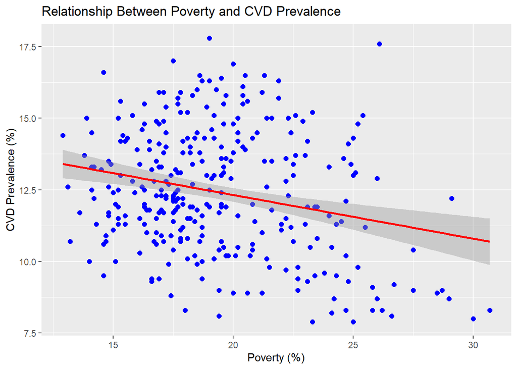

```r
ggplot(data, aes(x = Poverty, y = CVD)) +
  geom_point(color = "blue", size = 2) +
  geom_smooth(method = "lm", se = TRUE, color = "red") +
  labs(title = "Relationship Between Poverty and CVD Prevalence",
       x = "Poverty (%)", y = "CVD Prevalence (%)")
```